# Semantic Web Technologies and Wikidata from R

Goran S. Milovanović

Wikimedia Deutschland, Data Scientist, DataKolektiv, Owner

Mike Page

DataKolektiv, Junior Data Scientist

11 June 2019

### Notebook 05: Reference Corpus: LDA Training for Document-Level WD Entitiy Disambiguation

**Feedback** should be send to `goran.milovanovic@datakolektiv.com`. These notebooks accompany the MilanoR talk 2019/06/25.

### 1. Setup

**Note.** The following chunks load packages, define the project directory tree and some constants.

```r
### --- setup

## - libraries
library(data.table)
library(tidyverse)
library(ggrepel)
library(stringr)
library(tm)
library(BBmisc)
library(text2vec)
library(snowfall)

### --- directories
dataDir <- 'data/'
analyticsDir <- 'analytics/'
funDir <- 'functions/'
```

### 2. Load Term-Document Frequency Matrices

**Note.** The following chunks load the `refCorpLDA_tdm_sparse` and `targetCorpLDA_tdm_sparse` sparse matrices.

```r
# - load:
# - vocabulary:
vocabulary <- readRDS(paste0(analyticsDir, "vocabulary.Rds"))
refCorpLDA_tdm_sparse_Documents <- readRDS(paste0(
  analyticsDir, "refCorpLDA_tdm_sparse_Documents.Rds")
  )
targetCorpLDA_tdm_sparse_Documents <- readRDS(paste0(
  analyticsDir, "targetCorpLDA_tdm_sparse_Documents.Rds")
  )
# - refCorpLDA_tdm_sparse, targetCorpLDA_tdm_sparse
refCorpLDA_tdm_sparse <- Matrix::readMM(
  paste0(analyticsDir, 'refCorpLDA_tdm_sparse.mtx')
)
refCorpLDA_tdm_sparse@Dimnames[[1]] <- vocabulary
refCorpLDA_tdm_sparse@Dimnames[[2]] <- refCorpLDA_tdm_sparse_Documents
# - refCorpLDA_tdm_sparse, targetCorpLDA_tdm_sparse
targetCorpLDA_tdm_sparse <- Matrix::readMM(
  paste0(analyticsDir, 'targetCorpLDA_tdm_sparse.mtx')
)
targetCorpLDA_tdm_sparse@Dimnames[[1]] <- vocabulary
targetCorpLDA_tdm_sparse@Dimnames[[2]] <- targetCorpLDA_tdm_sparse_Documents

# - transpose the matrices
# - for {text2vec} so that column names == terms:
refCorpLDA_tdm_sparse <- Matrix::t(refCorpLDA_tdm_sparse)
targetCorpLDA_tdm_sparse <- Matrix::t(targetCorpLDA_tdm_sparse)
```

### 3.1 LDA Training Phase 1: 10:10:500 topics, 3 LDA runs for each number of topics.

**Note.** We train the whole Reference Corpus (English Wikidata pages:`refCorpLDA_tdm_sparse`) and evaluate by the model perplexity over the Target Corpus (news: `targetCorpLDA_tdm_sparse`). In the previous Notebook we have aligned these two corpora to use the same vocabulary, so the two TDMs are also aligned in that respect.

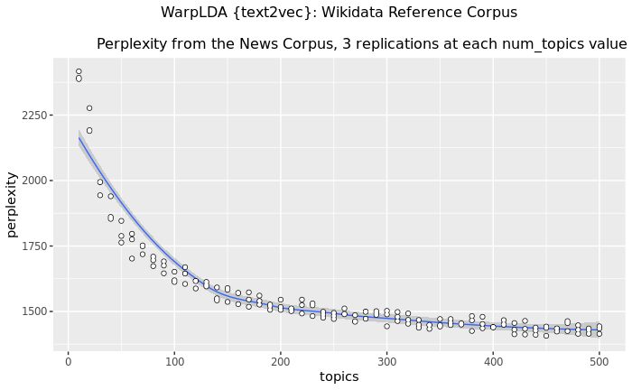

### 3.2 LDA Training Phase 2: 500:10:1000 topics, 3 LDA runs for each number of topics.

More training: 510:1000 topics, by 10.

```r
### ----------------------------------------------------------
### --- LDA training: refCorpLDA_tdm_sparse
### --- topics: 510:1000, by = 10
### --- number of replications: 3
### ----------------------------------------------------------

# - keep results from Phase 1
modelFrame_previous <- modelFrame

# - params
# - topic range:
nTops <- seq(510, 1000, by = 10)
# - number of replications at each topic:
n_repl <- 3

# - initiate cluster:
sfInit(parallel = TRUE,
       cpus = 7)
```

```
snowfall 1.84-6.1 initialized (using snow 0.4-3): parallel execution on 7 CPUs.
```

```r
# - export
sfExport("nTops")
sfExport("refCorpLDA_tdm_sparse")
sfExport("targetCorpLDA_tdm_sparse")
sfLibrary(text2vec)
```

```
Library text2vec loaded.
```

```
Library text2vec loaded in cluster.
```

```r
### --- Iterate: n_repl replications
repl_perplexity <- vector(mode = "list", length = n_repl)

for (i in 1:n_repl) {

  # - train in parallel:
  # - train:
  print(paste0("---------------- Running replication: ", i))
  t1 <- Sys.time()
  print(paste0("Training starts:", t1))
  modelPerplexity <- sfClusterApplyLB(nTops,
                                      function(x) {
                                        # - define model:
                                        # - alpha:
                                        doc_topic_prior = 50/x
                                        # - beta:
                                        topic_word_prior = 1/x
                                        # - lda_model:
                                        lda_model <- LatentDirichletAllocation$new(n_topics = x,
                                                                                              doc_topic_prior,
                                                                                              topic_word_prior)
                                        # - train:
                                        doc_topic_distr <- lda_model$fit_transform(refCorpLDA_tdm_sparse,
                                                                                   n_iter = 100,
                                                                                   convergence_tol = -1,
                                                                                   n_check_convergence = 25,
                                                                                   progressbar = FALSE)
                                        # - compute perplexity:
                                        new_doc_topic_distr = lda_model$transform(targetCorpLDA_tdm_sparse)
                                        return(
                                          perplexity(targetCorpLDA_tdm_sparse,
                                                                topic_word_distribution = lda_model$topic_word_distribution,
                                                                doc_topic_distribution = new_doc_topic_distr)
                                        )
                                      })

  print(paste0("Training ends:", Sys.time()))
  print(paste0("Training took: ", Sys.time() - t1))

  # - store perplexities from i-th replication:
  modelFrame <- data.frame(topics = nTops,
                           perplexity = unlist(modelPerplexity),
                           replication = i,
                           stringsAsFactors = F)
  repl_perplexity[[i]] <- modelFrame
  print(paste0("---------------- Completed replication: ", i))

}
```

```
[1] "---------------- Running replication: 1"
[1] "Training starts:2019-06-11 01:43:17"
[1] "Training ends:2019-06-11 02:49:15"
[1] "Training took: 1.09948965185218"
[1] "---------------- Completed replication: 1"
[1] "---------------- Running replication: 2"
[1] "Training starts:2019-06-11 02:49:15"
[1] "Training ends:2019-06-11 03:54:51"
[1] "Training took: 1.09338710592853"
[1] "---------------- Completed replication: 2"
[1] "---------------- Running replication: 3"
[1] "Training starts:2019-06-11 03:54:51"
[1] "Training ends:2019-06-11 04:59:59"
[1] "Training took: 1.08544372313552"
[1] "---------------- Completed replication: 3"
```

```r
# - stop cluster
sfStop()
```

```
Stopping cluster
```

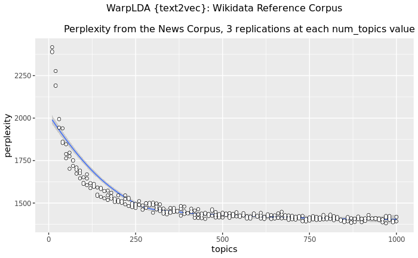

```r
# - Collect results:
modelFrame <- rbindlist(repl_perplexity)

# - Store results:
write.csv(modelFrame,
          paste0(analyticsDir, "modelFrame_Phase_2.csv"))


# - rbind with the results from Phase 1:
modelFrame <- rbind(modelFrame, modelFrame_previous)

# - Inspect results:
ggplot(modelFrame, aes(x = topics,
                       y = perplexity)) +
  stat_smooth(method="loess", size = .5, fullrange=TRUE) +
  xlim(10, 1000) +
  geom_point(size = 1.5, color = "black") +
  geom_point(size = 1, color = "white") +
  ggtitle("WarpLDA {text2vec}: Wikidata Reference Corpus\n
          Perplexity from the News Corpus, 3 replications at each num_topics value") +
  theme(plot.title = element_text(size = 12, hjust = 0.5))
```

### 3.3 LDA Training Phase 3: 1010:10:1500 topics, 3 LDA runs for each number of topics.

More training: 1010:1500 topics, by 10.

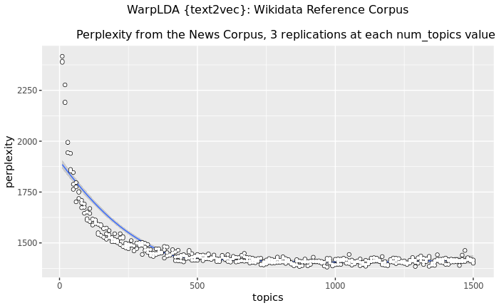

### 3.4 LDA Training Phase 4: 1510:10:2000 topics, 3 LDA runs for each number of topics.

More training: 1510:2000 topics, by 10.

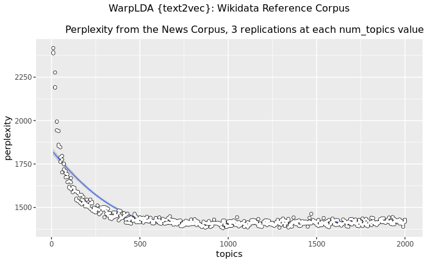

### 3.5 Mean Perplexity: Select LDA Model

Check the mean perplexity profile across the topics.

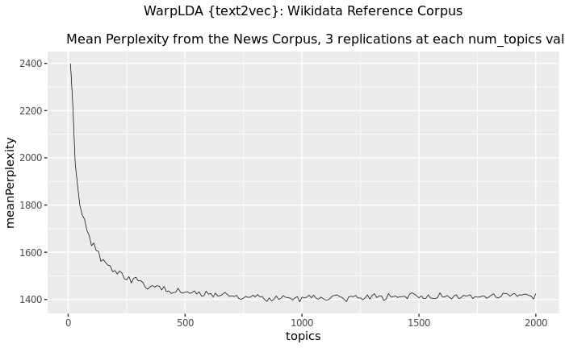

```r
selectModel <- modelFrame %>%
  group_by(topics) %>%
  summarise(meanPerplexity = mean(perplexity))

# - Plot mean perplexity from 3 replications:
ggplot(selectModel, aes(x = topics,
                        y = meanPerplexity)) +
  geom_line(size = .25) +
  ggtitle("WarpLDA {text2vec}: Wikidata Reference Corpus\n
          Mean Perplexity from the News Corpus, 3 replications at each num_topics value") +
  theme(plot.title = element_text(size = 12, hjust = 0.5))
```

### 3.6 LDA Training Phase 5: 2010:10:2500 topics, 3 LDA runs for each number of topics.

More training: 2010:2500 topics, by 10.

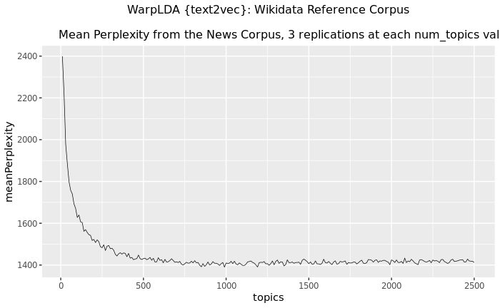

### 3.7 LDA Training Phase 5: 2510:10:3000 topics, 3 LDA runs for each number of topics.

More training: 2510:3000 topics, by 10.

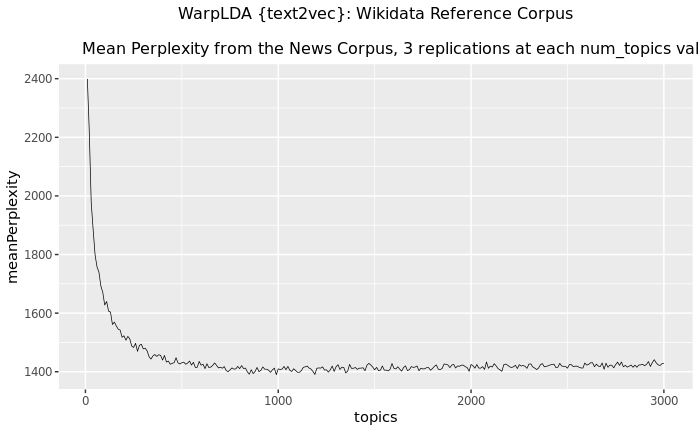

### 3.8 LDA Training: Selected Reference Model, 1000 topics, 20 replications.

We now select the model with minimal perplexity (around 1,000 topics) and train LDA w. 20 replications. Again, we select by perplexity over the Target (news) corpus.

```r
### ----------------------------------------------------------
### --- LDA training: train the selected refCorpLDA_tdm_sparse
### --- model: 1000 topics
### --- number of replications: 20
### ----------------------------------------------------------

### --- Iterate: n_repl replications
# - params
# - number of replications:
n_repl = 20
nTops <- rep(1000, n_repl)

# - initiate cluster:
sfInit(parallel = TRUE,
       cpus = 7)
# - export
sfExport("nTops")
sfExport("refCorpLDA_tdm_sparse")
sfExport("targetCorpLDA_tdm_sparse")
sfLibrary(text2vec)

t1 <- Sys.time()
print(paste0("Training starts:", t1))
ldaModels <- sfClusterApplyLB(nTops,
                              function(x) {
                                # - define model:
                                # - alpha:
                                doc_topic_prior = 50/x
                                # - beta:
                                topic_word_prior = 1/x
                                # - lda_model:
                                lda_model <- text2vec:::LatentDirichletAllocation$new(n_topics = x,
                                                                                      doc_topic_prior,
                                                                                      topic_word_prior)
                                # - train:
                                doc_topic_distr <- lda_model$fit_transform(refCorpLDA_tdm_sparse,
                                                                           n_iter = 1000,
                                                                           convergence_tol = -1,
                                                                           n_check_convergence = 25,
                                                                           progressbar = FALSE)
                                # - compute perplexity:
                                new_doc_topic_distr = lda_model$transform(targetCorpLDA_tdm_sparse)
                                perplexity <- text2vec:::perplexity(targetCorpLDA_tdm_sparse,
                                                                    topic_word_distribution = lda_model$topic_word_distribution,
                                                                    doc_topic_distribution = new_doc_topic_distr)

                                # - outputs
                                out <- list()
                                out$lda_model <- lda_model
                                out$doc_topic_distr <- doc_topic_distr
                                out$new_doc_topic_distr <- new_doc_topic_distr
                                out$perplexity <- perplexity
                                return(out)
                              })

print(paste0("Training starts:", Sys.time()))
print(paste0("Training took: ", Sys.time() - t1))

# - store final models
saveRDS(ldaModels, paste0(analyticsDir,
                          "Final_LDA_Models.rds"))

# - store perplexities from the final model:
final_modelFrame <- data.frame(model_index = 1:length(nTops),
                               topics = nTops,
                               perplexity = sapply(ldaModels, function(x) {x$perplexity}),
                               stringsAsFactors = F)
write.csv(final_modelFrame, paste0(analyticsDir,
                                   "final_model_Perplexities.csv"))

# - stop cluster
sfStop()

### - final_modelFrame
ggplot(final_modelFrame, aes(x = model_index,
                             y = perplexity,
                             label = model_index)) +
  geom_line(size = .25, color = "red", group = 1) +
  geom_point(size = 1.5, color = "black") +
  geom_point(size = 1, color = "white") +
  geom_text_repel() +
  ggtitle("WarpLDA {text2vec}: 10 replications of the best (nTops=1000) LDA model") +
  theme(plot.title = element_text(size = 12, hjust = 0.5))

# - select final model
ldaModel <- ldaModels[[which.min(sapply(ldaModels, function(x) {x$perplexity}))]]
rm(ldaModels)
# - save final model
saveRDS(ldaModel,
        paste0(analyticsDir, "Seletected_LDA_Model.Rds"))
```

[output not shown]

Goran S. Milovanović & Mike Page

DataKolektiv, 2019.

contact: datakolektiv@datakolektiv.com

License: [GPLv3](http://www.gnu.org/licenses/gpl-3.0.txt) This Notebook is free software: you can redistribute it and/or modify it under the terms of the GNU General Public License as published by the Free Software Foundation, either version 3 of the License, or (at your option) any later version. This Notebook is distributed in the hope that it will be useful, but WITHOUT ANY WARRANTY; without even the implied warranty of MERCHANTABILITY or FITNESS FOR A PARTICULAR PURPOSE. See the GNU General Public License for more details. You should have received a copy of the GNU General Public License along with this Notebook. If not, see http://www.gnu.org/licenses/.